# Time Series of CO2 Levels

Working With Prophet to Model Changes in CO2

Anna Szulc

March 2024

### The purpose of this project

The purpose of this project is to explore CO2 data using the prophet forecasting system by Meta in R. It’s aimed to provide practical experience with using and analysing time series to enhance CV’s. This project is created to expand our skill profile and strengthen our professional portfolio for future employability and CV’s by enhancing our skills in data analytics and R programming.

### What is CO2

In this project CO2 refers to the atmospheric concentrations of CO2 expressed in parts per million (ppm). It is a time series of 468 observations collected monthly from 1959 to 1997. This was reported in the preliminary 1997 SOI manometric mole fraction scale.

To run all the following functions fromt he prophet library I fist had to insatll ‘install.packages(“prophet”)’ and from this install ‘install.packages(“remotes”)’ and ‘remotes::install_github(’facebook/prophet@*release’, subdir=‘R’)‘. Only then was I able to run ’library(prophet)’.

### Plotting time series

Using the ‘make_future_dataframe’ and ‘predict’ functions I will produce a plot of the Time series of recorded and predicted levels of CO2 levels.

```r
library(prophet)
co2.df = data.frame(
  ds=zoo::as.yearmon(time(co2)),
  y=co2)
m = prophet::prophet(co2.df)
```

```
## Disabling weekly seasonality. Run prophet with weekly.seasonality=TRUE to override this.
```

```
## Disabling daily seasonality. Run prophet with daily.seasonality=TRUE to override this.
```

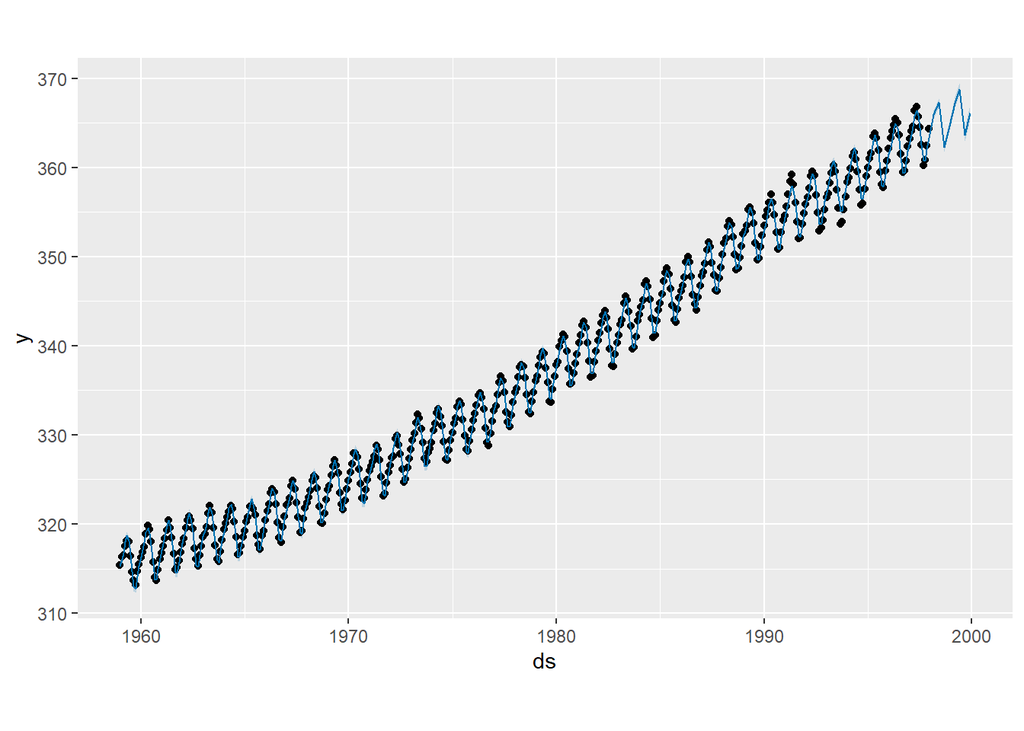

```r
f = prophet::make_future_dataframe(m, periods=8, freq="quarter")
p = predict(m, f)
plot(m,p)
```

From looking at this graph i can tell that CO2 levels have been constantly increasing from 1959 to 1997 with some small fluctuations within the years.

### Plotting Trend and Seasonality

To take a closer look at these fluctuations I will use the ‘prophet_plot_components’ function to deconstruct this graph into trend and seasonality.

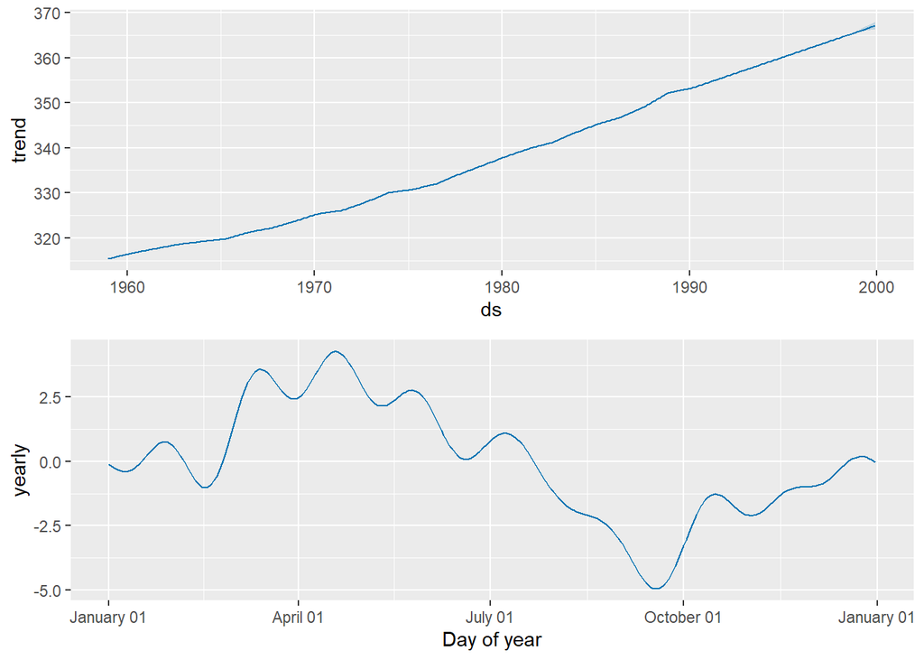

```r
prophet_plot_components(m,p)
```

### Linear Regression Model

I will run a linear regression model to undersatnd the time series a bit more.

```r
lin_model = lm(y~ds, data=co2.df)
summary(lin_model)
```

```
##
## Call:
## lm(formula = y ~ ds, data = co2.df)
##
## Residuals:
##     Min      1Q  Median      3Q     Max
## -6.0399 -1.9476 -0.0017  1.9113  6.5149
##
## Coefficients:
##               Estimate Std. Error t value Pr(>|t|)
## (Intercept) -2.250e+03  2.127e+01  -105.8   <2e-16 ***
## ds           1.308e+00  1.075e-02   121.6   <2e-16 ***
## ---
## Signif. codes:  0 '***' 0.001 '**' 0.01 '*' 0.05 '.' 0.1 ' ' 1
##
## Residual standard error: 2.618 on 466 degrees of freedom
## Multiple R-squared:  0.9695, Adjusted R-squared:  0.9694
## F-statistic: 1.479e+04 on 1 and 466 DF,  p-value: < 2.2e-16
```

This data is telling me that for each increase in time, CO2 levels increase by 1.308e+00 ppm.This data shows that the linear regression model fits the actual CO2 data well.

### Histogram

Histogram of CO2 data:

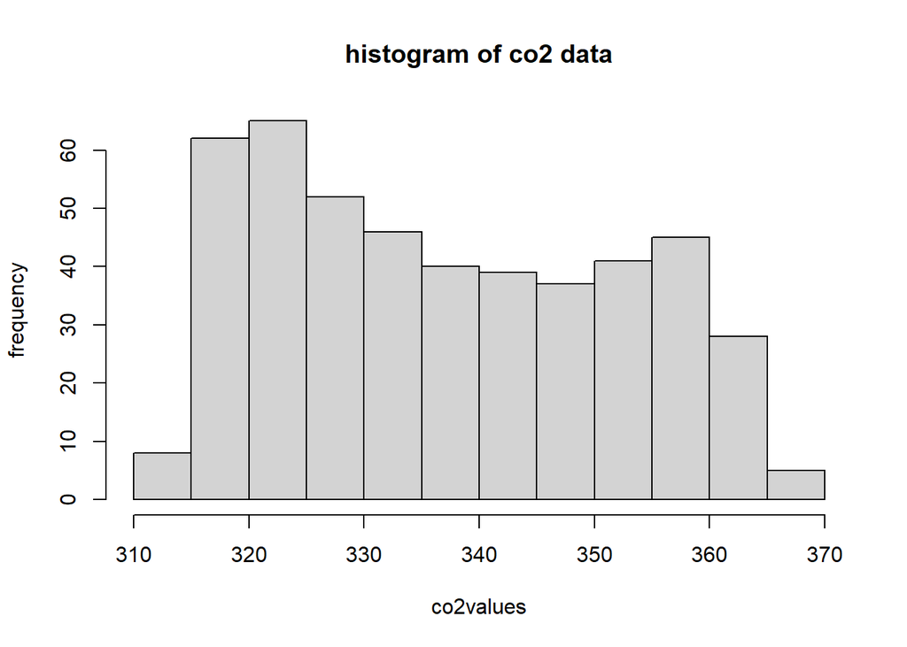

```r
hist(co2.df$y, main="histogram of co2 data", ylab="frequency", xlab="co2values")
```

From this Histogram we can see that the most common CO2 levels were between 320 to 325 ppm and the least common levels of CO2 levels recorded were between 365 to 370 ppm.the difference between the different bar classes, apart from the 310-315 and 365-370 classes, shows that the CO2 increase in CO2 levels was gradual but is speeding up over time as the frequency between classes decreases.

### Boxplot

Boxplot of CO2 data:

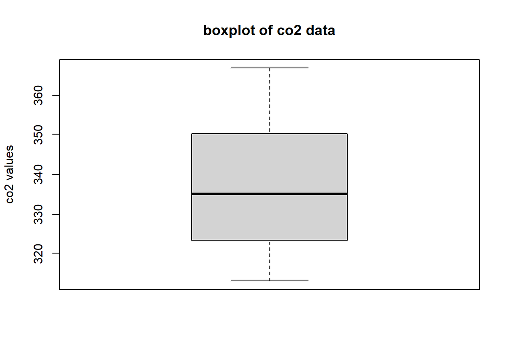

```r
boxplot(co2.df$y, main="boxplot of co2 data", ylab="co2 values")
```

From the boxplot we can see that the upper tail is slightly longer than the lower tail. This also supports my claim that CO2 particles are increasing faster the median is slightly skewed down in the box also supporting this.

### Looking at numbers of interest

Lets summarise the co2 data frame to understand it better.

```r
summary(co2.df)
```

```
##        ds             y
##  Min.   :1959   Min.   :313.2
##  1st Qu.:1969   1st Qu.:323.5
##  Median :1978   Median :335.2
##  Mean   :1978   Mean   :337.1
##  3rd Qu.:1988   3rd Qu.:350.3
##  Max.   :1998   Max.   :366.8
```

This shows the numerical data of the boxplot above. We can see that the difference between quartile 3 and maximum is 16.5 while the difference between the minimum and quartile 1 is 10.3 further supporting my claim that CO2 levels are not only increasing but increasing faster.

Lets summarise the prediction data to see what it is telling us.

```r
summary(p)
```

```
##        ds                              trend       additive_terms
##  Min.   :1959-01-01 00:00:00.000   Min.   :315.4   Min.   :-3.36507
##  1st Qu.:1968-11-23 12:00:00.000   1st Qu.:323.6   1st Qu.:-1.50939
##  Median :1978-10-16 12:00:00.000   Median :335.8   Median : 0.24471
##  Mean   :1978-10-20 22:23:11.597   Mean   :337.6   Mean   :-0.03166
##  3rd Qu.:1988-09-08 12:00:00.000   3rd Qu.:351.8   3rd Qu.: 1.64891
##  Max.   :1999-12-01 00:00:00.000   Max.   :367.1   Max.   : 3.02022
##  additive_terms_lower additive_terms_upper     yearly
##  Min.   :-3.36507     Min.   :-3.36507     Min.   :-3.36507
##  1st Qu.:-1.50939     1st Qu.:-1.50939     1st Qu.:-1.50939
##  Median : 0.24471     Median : 0.24471     Median : 0.24471
##  Mean   :-0.03166     Mean   :-0.03166     Mean   :-0.03166
##  3rd Qu.: 1.64891     3rd Qu.: 1.64891     3rd Qu.: 1.64891
##  Max.   : 3.02022     Max.   : 3.02022     Max.   : 3.02022
##   yearly_lower       yearly_upper      multiplicative_terms
##  Min.   :-3.36507   Min.   :-3.36507   Min.   :0
##  1st Qu.:-1.50939   1st Qu.:-1.50939   1st Qu.:0
##  Median : 0.24471   Median : 0.24471   Median :0
##  Mean   :-0.03166   Mean   :-0.03166   Mean   :0
##  3rd Qu.: 1.64891   3rd Qu.: 1.64891   3rd Qu.:0
##  Max.   : 3.02022   Max.   : 3.02022   Max.   :0
##  multiplicative_terms_lower multiplicative_terms_upper   yhat_lower
##  Min.   :0                  Min.   :0                  Min.   :312.3
##  1st Qu.:0                  1st Qu.:0                  1st Qu.:323.1
##  Median :0                  Median :0                  Median :335.4
##  Mean   :0                  Mean   :0                  Mean   :337.1
##  3rd Qu.:0                  3rd Qu.:0                  3rd Qu.:350.5
##  Max.   :0                  Max.   :0                  Max.   :368.1
##    yhat_upper     trend_lower     trend_upper         yhat
##  Min.   :313.2   Min.   :315.4   Min.   :315.4   Min.   :312.7
##  1st Qu.:324.0   1st Qu.:323.6   1st Qu.:323.6   1st Qu.:323.6
##  Median :336.3   Median :335.8   Median :335.8   Median :335.8
##  Mean   :338.0   Mean   :337.6   Mean   :337.6   Mean   :337.5
##  3rd Qu.:351.5   3rd Qu.:351.8   3rd Qu.:351.8   3rd Qu.:351.0
##  Max.   :369.5   Max.   :366.4   Max.   :368.0   Max.   :368.8
```

This summary shows the data for the trend, seasonality and predicted values. It shows how many factors the ‘Predict’ function considers to provide an accurate forecasting. We can see the statistics of each component above.

Lets look at the fist 6 and last 6 values of the predicted data.

```r
head(p)
```

```
##           ds    trend additive_terms additive_terms_lower additive_terms_upper
## 1 1959-01-01 315.3537    -0.07753751          -0.07753751          -0.07753751
## 2 1959-02-01 315.4387     0.59487739           0.59487739           0.59487739
## 3 1959-03-01 315.5155     1.23263039           1.23263039           1.23263039
## 4 1959-04-01 315.6005     2.46038945           2.46038945           2.46038945
## 5 1959-05-01 315.6828     3.02022342           3.02022342           3.02022342
## 6 1959-06-01 315.7678     2.35150786           2.35150786           2.35150786
##        yearly yearly_lower yearly_upper multiplicative_terms
## 1 -0.07753751  -0.07753751  -0.07753751                    0
## 2  0.59487739   0.59487739   0.59487739                    0
## 3  1.23263039   1.23263039   1.23263039                    0
## 4  2.46038945   2.46038945   2.46038945                    0
## 5  3.02022342   3.02022342   3.02022342                    0
## 6  2.35150786   2.35150786   2.35150786                    0
##   multiplicative_terms_lower multiplicative_terms_upper yhat_lower yhat_upper
## 1                          0                          0   314.7817   315.7429
## 2                          0                          0   315.6017   316.5158
## 3                          0                          0   316.3089   317.2118
## 4                          0                          0   317.5708   318.5145
## 5                          0                          0   318.2193   319.1720
## 6                          0                          0   317.6465   318.5891
##   trend_lower trend_upper     yhat
## 1    315.3537    315.3537 315.2762
## 2    315.4387    315.4387 316.0336
## 3    315.5155    315.5155 316.7481
## 4    315.6005    315.6005 318.0609
## 5    315.6828    315.6828 318.7030
## 6    315.7678    315.7678 318.1193
```

```r
tail(p)
```

```
##             ds    trend additive_terms additive_terms_lower
## 471 1998-09-01 365.3458     -3.0869040           -3.0869040
## 472 1998-12-01 365.6985     -0.9752536           -0.9752536
## 473 1999-03-01 366.0474      1.2326304            1.2326304
## 474 1999-06-01 366.4040      2.3515079            2.3515079
## 475 1999-09-01 366.7606     -3.0559696           -3.0559696
## 476 1999-12-01 367.1133     -0.9773037           -0.9773037
##     additive_terms_upper     yearly yearly_lower yearly_upper
## 471           -3.0869040 -3.0869040   -3.0869040   -3.0869040
## 472           -0.9752536 -0.9752536   -0.9752536   -0.9752536
## 473            1.2326304  1.2326304    1.2326304    1.2326304
## 474            2.3515079  2.3515079    2.3515079    2.3515079
## 475           -3.0559696 -3.0559696   -3.0559696   -3.0559696
## 476           -0.9773037 -0.9773037   -0.9773037   -0.9773037
##     multiplicative_terms multiplicative_terms_lower multiplicative_terms_upper
## 471                    0                          0                          0
## 472                    0                          0                          0
## 473                    0                          0                          0
## 474                    0                          0                          0
## 475                    0                          0                          0
## 476                    0                          0                          0
##     yhat_lower yhat_upper trend_lower trend_upper     yhat
## 471   361.7678   362.7876    365.2789    365.4793 362.2589
## 472   364.2120   365.2999    365.5389    365.9559 364.7233
## 473   366.7217   367.9600    365.7815    366.4510 367.2800
## 474   368.1440   369.4755    365.9936    366.9546 368.7555
## 475   362.9700   364.5063    366.2477    367.4708 363.7046
## 476   365.3128   367.0890    366.4153    367.9790 366.1360
```

From all the above data summarised we can see the first 6 and last 6 pieces of data.

Lets look at the last 6 values of the future dataframe.

```r
tail(f)
```

```
##             ds
## 471 1998-09-01
## 472 1998-12-01
## 473 1999-03-01
## 474 1999-06-01
## 475 1999-09-01
## 476 1999-12-01
```

This is showing the last 6 dates of data predicted.

Lets summarise the Prophet model.

```r
summary(m)
```

```
##                         Length Class      Mode
## growth                    1    -none-     character
## changepoints             25    POSIXct    numeric
## n.changepoints            1    -none-     numeric
## changepoint.range         1    -none-     numeric
## yearly.seasonality        1    -none-     character
## weekly.seasonality        1    -none-     character
## daily.seasonality         1    -none-     character
## holidays                  0    -none-     NULL
## seasonality.mode          1    -none-     character
## seasonality.prior.scale   1    -none-     numeric
## changepoint.prior.scale   1    -none-     numeric
## holidays.prior.scale      1    -none-     numeric
## mcmc.samples              1    -none-     numeric
## interval.width            1    -none-     numeric
## uncertainty.samples       1    -none-     numeric
## specified.changepoints    1    -none-     logical
## start                     1    POSIXct    numeric
## y.scale                   1    -none-     numeric
## logistic.floor            1    -none-     logical
## t.scale                   1    -none-     numeric
## changepoints.t           25    -none-     numeric
## seasonalities             1    -none-     list
## extra_regressors          0    -none-     list
## country_holidays          0    -none-     NULL
## stan.fit                  4    -none-     list
## params                    6    -none-     list
## history                   5    data.frame list
## history.dates           468    POSIXct    numeric
## train.holiday.names       0    -none-     NULL
## train.component.cols      3    data.frame list
## component.modes           2    -none-     list
## fit.kwargs                0    -none-     list
```

This summary shows how the prophet function works and the different factors it considers an detects.

### Conclution

Starting this project and seeing the time series plot, it seemed to me that CO2 particle levels were increasing linearly but after considering the Boxplot and Histogram its seems more likely to me that the levels are increasing exponentially. Looking at the seasonality graph shows us that there are multiple factors that affect CO2 levels throughout the year as well.